# Séance 1.3: Données digitales

Collecte par interfaces de programmation d’applications (API)

Visseho Adjiwanou, PhD.

12 June 2021

# Plan de présentation

- Définition
  - Application programming interface (API)
  - Type de fichiers API
- Type de fichiers
- Object de R: liste
- Exemples d’utilisation de API pour la collecte de données
  - API de crossref
  - API de twitter
  - API de DHS
  - API de IPUMS

# API

# Définition

# Qu’est-ce qu’une interface de programmation d’application (applicative)?

- Les API sont des outils permettant de créer des applications ou d’autres formes de logiciels permettant aux utilisateurs d’accéder à certaines parties de bases de données volumineuses.
- Les développeurs de logiciels peuvent combiner ces outils de différentes manières, ou avec des outils d’autres API, afin de générer des outils encore plus utiles.
- La plupart d’entre nous utilisons ces applications chaque jour.
- Par exemple, si vous installez l’application Spotify sur votre page Facebook pour partager de la musique avec vos amis, cette application extrait des données de l’API de Spotify, puis les publie sur votre page Facebook en communiquant avec l’API de Facebook.
- Il existe d’innombrables exemples de ce type sur Internet à l’heure actuelle.
- **En résumé, Une API permet à deux applications de communiquer entre elles**.

# Comment fonctionne une API?

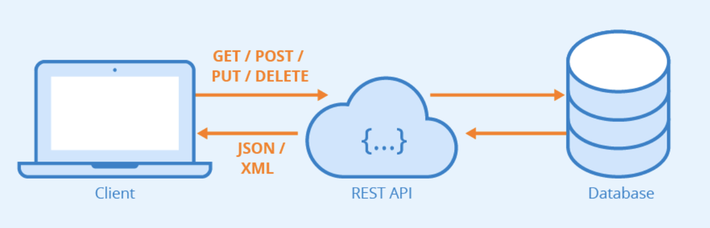

# Comment fonctionne une API? Exemple avec crossnef

- Supposer que vous voulez collecter les articles publiés sur la Covid-19
- Pour cela, vous devez envoyer une requête au site, c’est-à-dire:
- indiquer le site
- indiquer la requête
- Pour plus d’information:  
  https://www.crossref.org/education/retrieve-metadata/rest-api/a-non-technical-introduction-to-our-api/
- https://github.com/ropensci/rcrossref
- https://ciakovx.github.io/rcrossref.html
- https://www.crossref.org/education/retrieve-metadata/rest-api/a-non-technical-introduction-to-our-api/

# Comment fonctionne une API? Exemple avec crossnef

- Cette requête: https://api.crossref.org/works?query=covid-19
- connecte avec le site crossnef pour collecter les informations sur les recherches sur la Covid-19
- Regardons un des résultats:
- https://api.crossref.org/works/10.1055/a-1229-5048

# Comment fonctionne une API? Exemple avec crossnef

{“status”:“ok”,“message-type”:“work”,“message-version”:“1.0.0”,“message”:{“indexed”:{“date-parts”:[[2020,11,3]],“date-time”:“2020-11-03T00:12:53Z”,“timestamp”:1604362373737},“reference-count”:0,“publisher”:“Georg Thieme Verlag KG”,“issue”:“04”,“content-domain”:{“domain”:[],“crossmark-restriction”:false},“short-container-title”:[“Endo-Praxis”],“published-print”:{“date-parts”:[[2020,11]]},“DOI”:“10.1055/a-1229-5048”,“type”:“journal-article”,“created”:{“date-parts”:[[2020,11,2]],“date-time”:“2020-11-02T23:41:05Z”,“timestamp”:1604360465000},“page”:“173-173”,“source”:“Crossref”,“is-referenced-by-count”:0,“title”:[“COVID-19 COVID-19 COVID-19 COVID-19 COVID-19 COVID-19”],“prefix”:“10.1055”,“volume”:“36”,“author”:[{“given”:“Rainer”,“family”:“Duchmann”,“sequence”:“additional”,“affiliation”:[{“name”:“Medizinischen Klinik, Hospital zum heiligen Geist GmbH, Frankfurt/Main”}]}],“member”:“194”,“published-online”:{“date-parts”:[[2020,11,2]]},“container-title”:[“Endo-Praxis”],“original-title”:[],“language”:“de”,“link”:[{“URL”:“http:\/\/www.thieme-connect.de\/products\/ejournals\/pdf\/10.1055\/a-1229-5048.pdf”,“content-type”:“unspecified”,“content-version”:“vor”,“intended-application”:“similarity-checking”}],“deposited”:{“date-parts”:[[2020,11,2]],“date-time”:“2020-11-02T23:41:07Z”,“timestamp”:1604360467000},“score”:1.0,“subtitle”:[],“short-title”:[],“issued”:{“date-parts”:[[2020,11]]},“references-count”:0,“journal-issue”:{“published-online”:{“date-parts”:[[2020,11,2]]},“published-print”:{“date-parts”:[[2020,11]]},“issue”:“04”},“URL”:“http:\/\/dx.doi.org\/10.1055\/a-1229-5048”,“relation”:{},“ISSN”:[“0177-4077”,“1611-6429”],“issn-type”:[{“value”:“0177-4077”,“type”:“print”},{“value”:“1611-6429”,“type”:“electronic”}]}}

# Type de fichiers

# Type de fichiers

- Les requêtes renvoient à des types de fichiers que nous ne traitons pas souvent en sciences sociales.
- Les principaux sont:
- XML: XML signifie eXtensible Markup Language
- html
- json

# Fichier xml

# Fichier xml

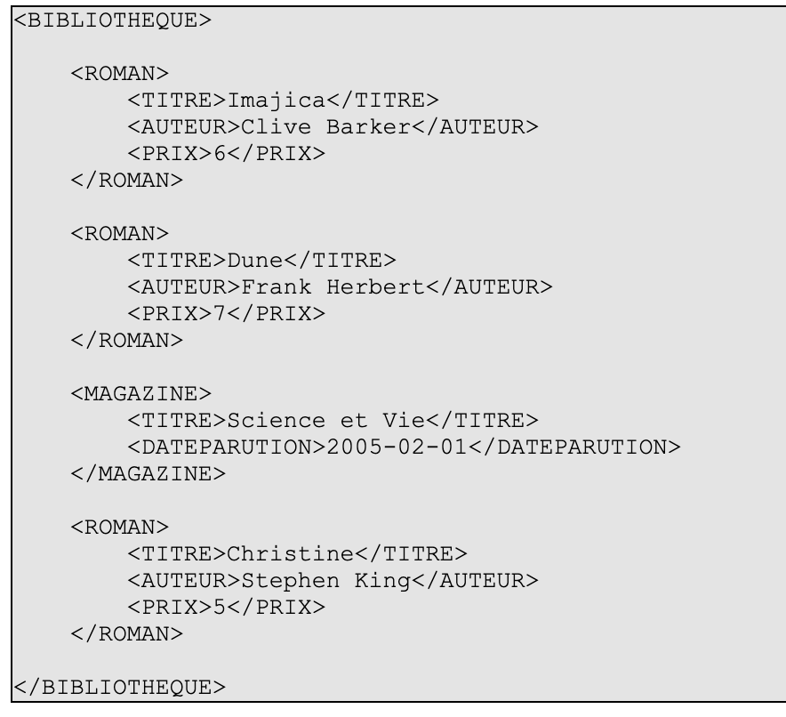

# Fichier xml: comment accéder aux données

- XQuery et XPath permettent d’extraire les informations qui vous intéresse d’un document XML
- Avec un package comme **XML** (voir exemple SOC8655_S10_xml.RMD)
- https://www.tutorialspoint.com/r/r_xml_files.htm

# Fichiers html

# Fichier JSON : Syntaxe

- **{…}** : les accolades définissent un objet.
- **“language”:“Java”** : Les guillemets (double-quotes) et les double-points définissent un couple clé/valeur (on parle de membre).
- **[…]** : Les crochets définissent un tableau (ou array en anglais).
- **,** : Les virgules permettent de séparer les membres d’un tableau ou, comme ici, d’un objet
- Exemple: **{“id”:1, “language”:“json”, “author”:“Douglas Crockford”}**

# Fichier JSON

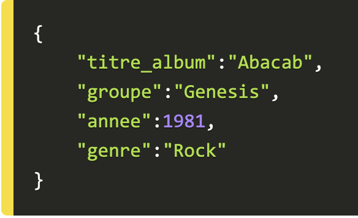

- Pour en savoir un peu plus: https://sebsauvage.net/comprendre/xml/

# Fichier JSON

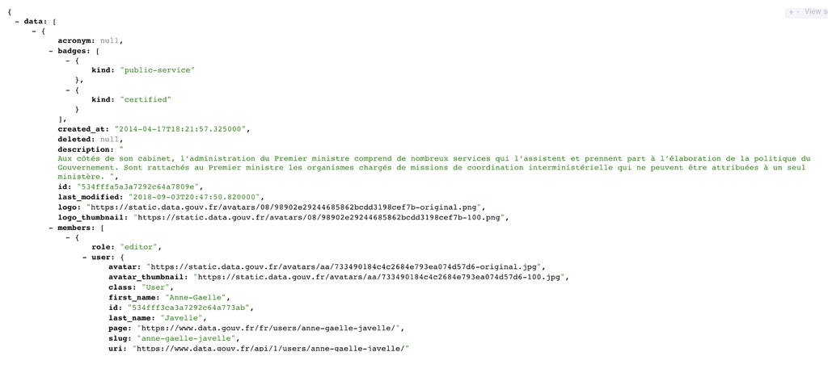

# Fichier JSON: Visualisation et validation

- Quand on débute dans un langage, le fait d’avoir à disposition des outils permettant de visualiser et de valider le code est d’une grande aide.
- Là encore json est doté de tout ce dont vous avez besoin.
- Plusieurs visualiseurs/validateurs sont disponibles en ligne.
- Un des visualiseurs les plus connu est jsonviewer.stack.hu.
- Le grand avantage de cet outil est qu’il intègre toutes les fonctionnalités utiles pour l’analyse d’un fragment de code .json :
- un validateur (très basique puisqu’il ne fait qu’indiquer si le code contient des erreurs),
- un visualiseur,
- un minificateur.

# Fichier JSON: Visualisation et validation

- Le principe est simple, vous collez le code dans la fenêtre “Text” puis vous cliquez sur l’onglet “Viewer”. S’il n’y a pas d’erreur dans votre code, l’arborescence de votre **.json** sera affichée.
- Copie d’écran pour le dernier exemple traité :

# Fichier JSON: Visualisation et validation

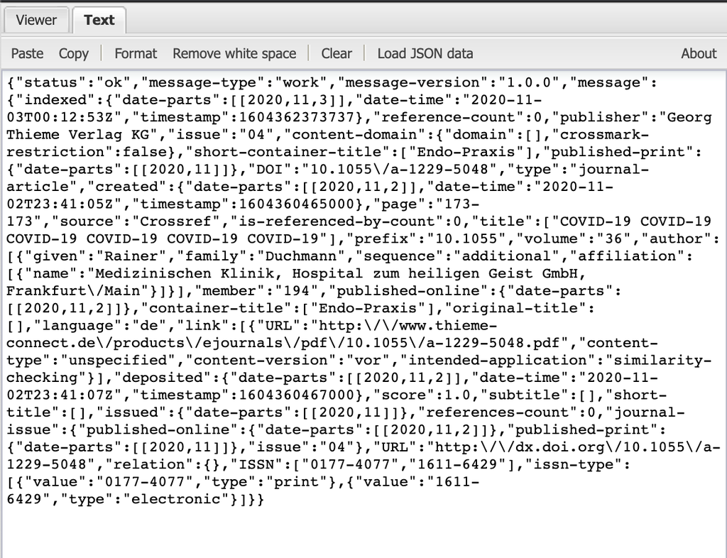

# Fichier JSON: Visualisation et validation

[figure not shown]

# Fichier JSON

- Pour plus d’information : https://www.alsacreations.com/article/lire/1675-json-stockage-leger-pratique-donnees-multitypes.html

# wrapper API

# Wrapper API

# Limitation de taux

# Limitation de taux

- La limitation des débits permet également aux grandes entreprises telles que Google, Facebook ou Twitter d’empêcher les développeurs de collecter de grandes quantités de données susceptibles de compromettre la confidentialité de leurs utilisateurs ou de menacer leur modèle commercial (car les données ont une si grande valeur dans l’économie actuelle).
- Le moment exact de la limitation de débit n’est pas toujours public, car connaître ces incréments de temps pourrait permettre aux développeurs de «jouer» au système et de faire des demandes rapides dès que la limitation de débit est terminée.

# Limitation de taux

- Cependant, certaines API vous permettent de passer un appel ou une requête à l’API afin de connaître le nombre de demandes supplémentaires que vous pouvez effectuer au cours d’une période donnée avant que votre taux ne soit limité.

# Un exemple avec l’API de Twitter

1. Obtenir les information d’identification : voir document partager sur Slack
2. Utiliser le package **rtweet** pour interagir avec le site

# Twitter API wrapper

- **rtweet** est un package de R qui permet de travailler avec le API de Twitter.
- Si vous n’avez pas ce package, vous devez apprendre à interagir directement avec le API en lisant toute la documentation le concernant: https://developer.twitter.com/en/docs/twitter-api
- Heureusement, pour la plupart des sites aujourd’hui, il y a un package qui interagit avec le site.

# rtweet

- rtweet permet de collecter : -1. des anciens **tweet** (jusqu’à 18000 - non retweet - tweets)
- **search_tweets** avec ses options -2. et des tweet qui se passent en direct (échantillon aléatoire (environ 1%) du flux en direct de tous les tweets)
- **stream_tweets** et ses options -3. et un ensemble d’autres informations

# rtweet : les autres principales fonctions de rtweet

- **get_friends** : récupérez une liste de tous les comptes **suivis** par un utilisateur.
- **get_followers** : récupérez une liste des comptes **qui suivent** un utilisateur.
- **get_timelines** : recevez les 3200 tweets les plus récents de cnn, BBC World et fox news.
- **get_favorites** : obtenez les 3000 derniers statuts favoris de quelqu’un.
- **search_users** : recherchez 1000 utilisateurs avec un spécifique **hashtag** dans leur profil.
- **get_trends** : découvrez les tendances actuelles dans un lieu.